# SNAG: T1 and T2 subfields

Shuying Yu

1/10/2022

# Overview

This report provides exploratory and preliminary correlation analyses between sex hormones and T1 and T2 hippocampal subfield data from the Healthy Aging Study sample (up to participant 383). No navigation behavioral data included (see prior analysis or PowerPoint).

I cleaned some of the data prior to analyses. I had to:

1. Filter participants that have either T1 or T2 subfield data from scan
2. Select sex hormone measures from when scan was conducted
3. Correct T1 and T2 subfield volumes using TIV from VBM
4. Average left and right volumes to get an average measure for each subfield and brain region

# T1 Volume

## Total Hippocampus

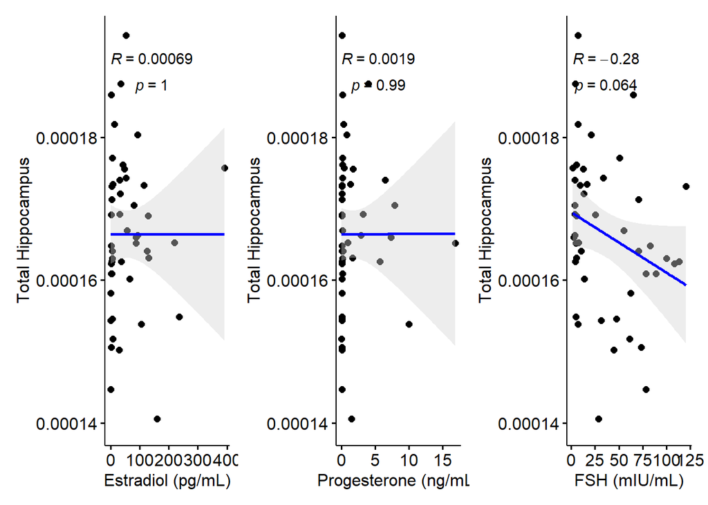

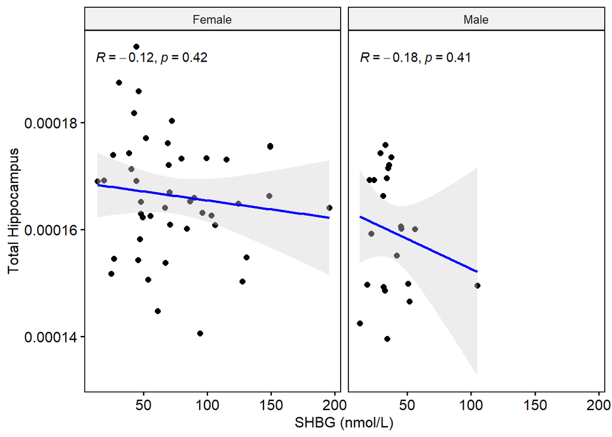

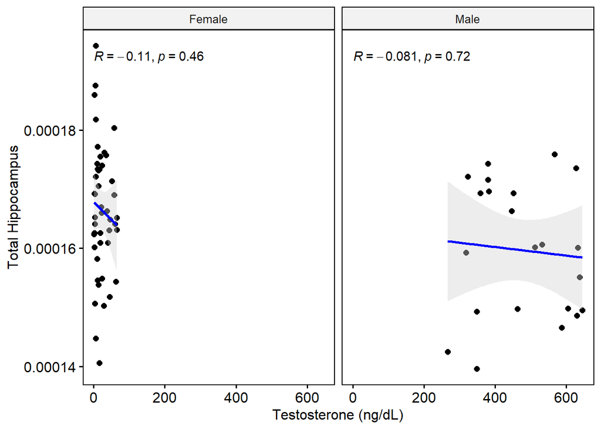

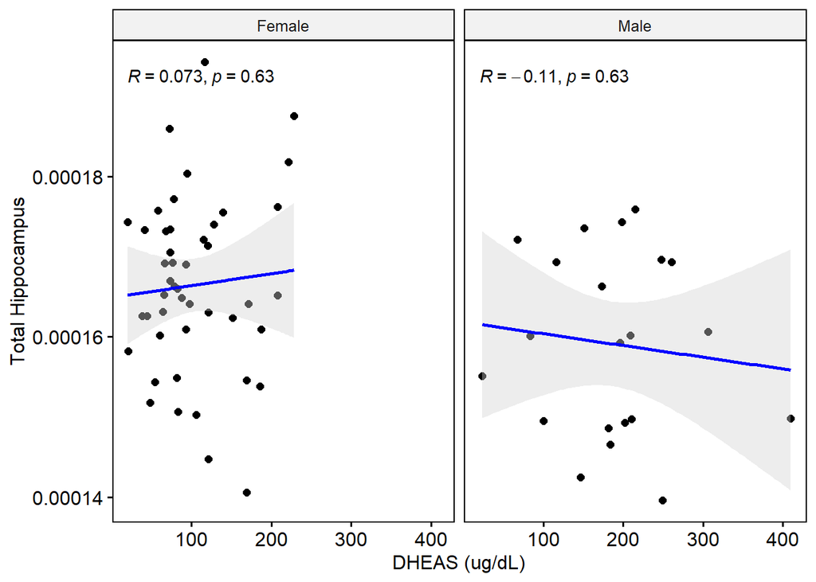

Total hippocampal volume has a merginal negative association with FSH

## Total GMV

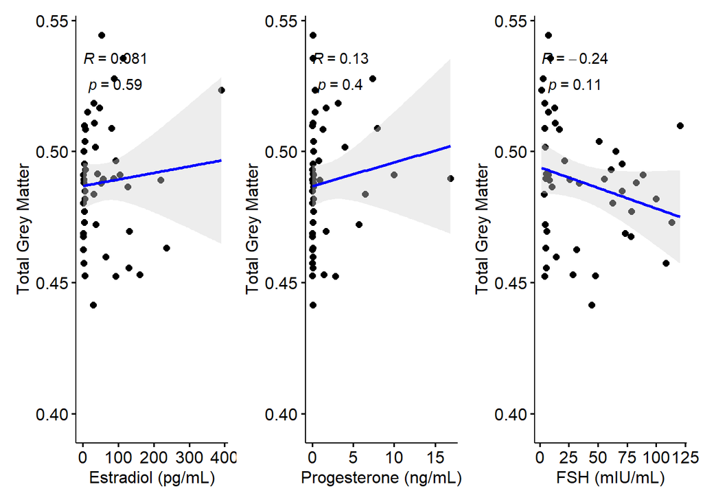

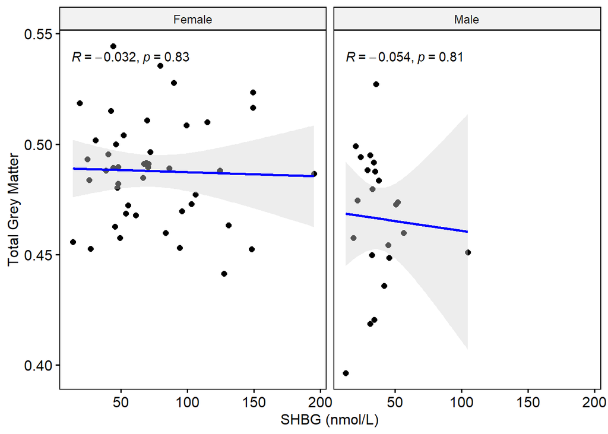

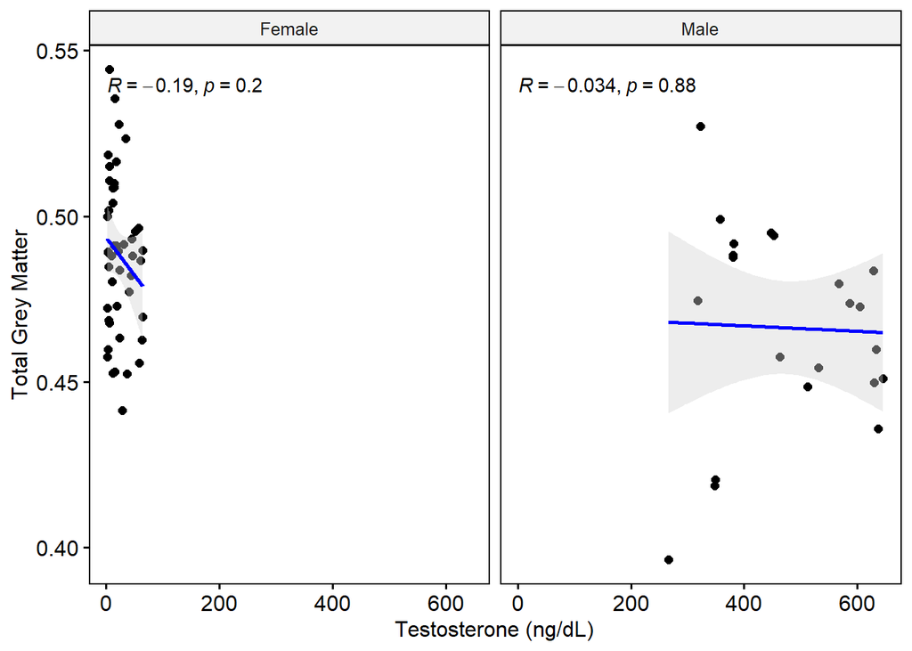

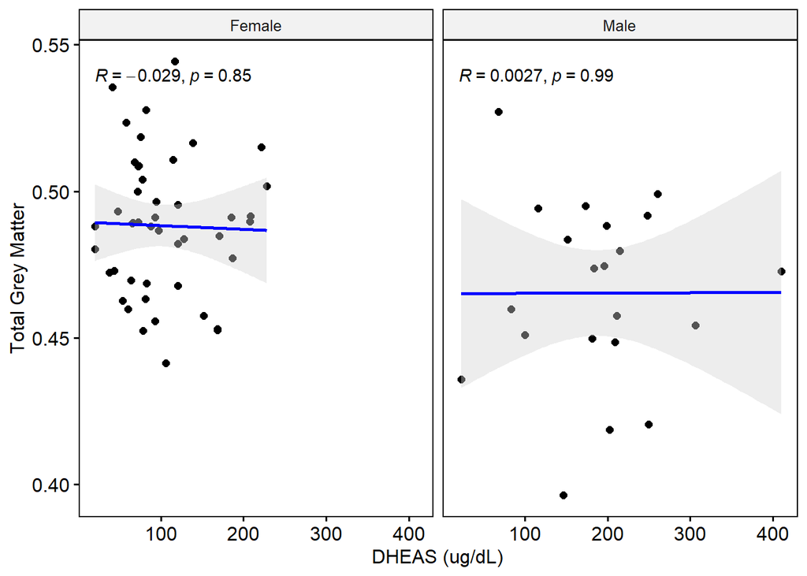

## MTL

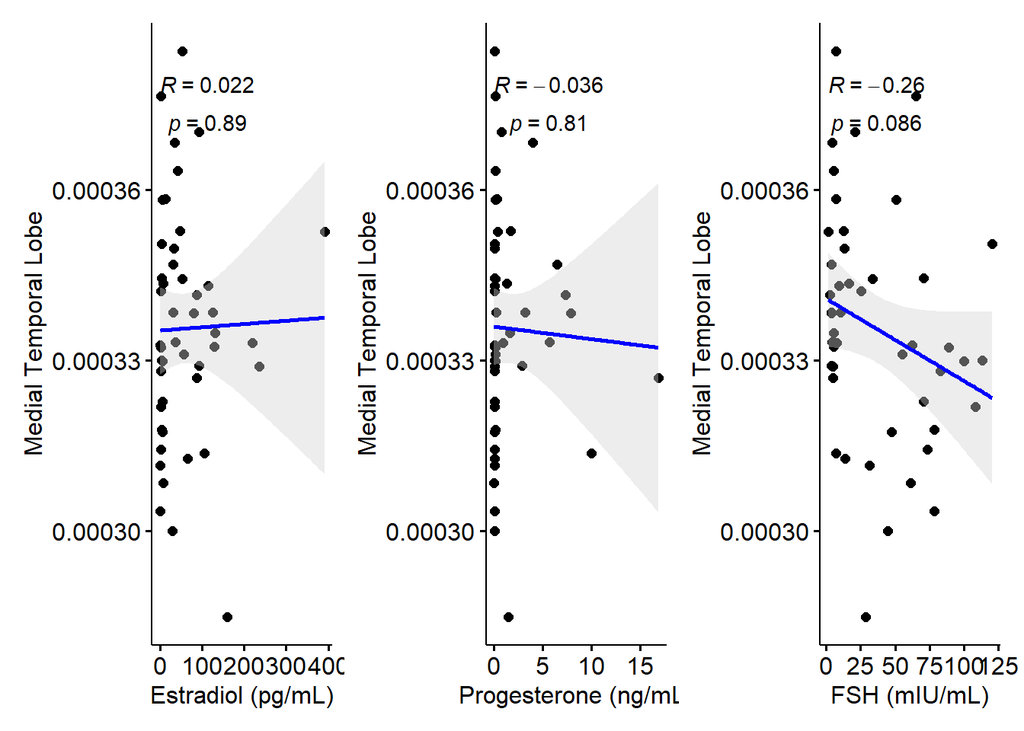

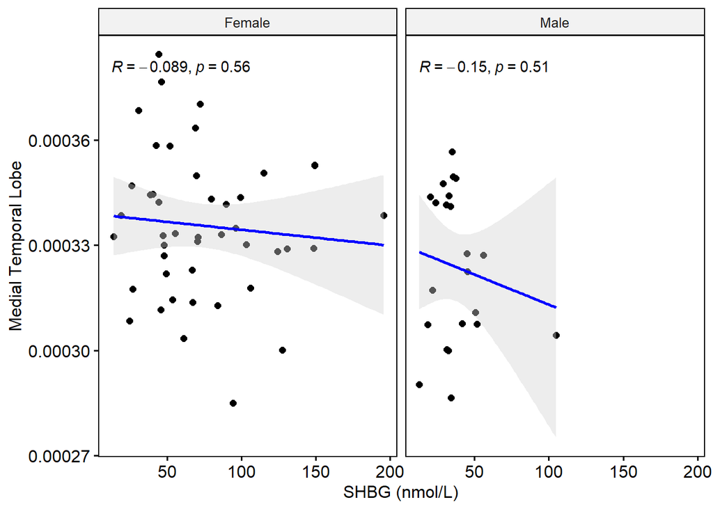

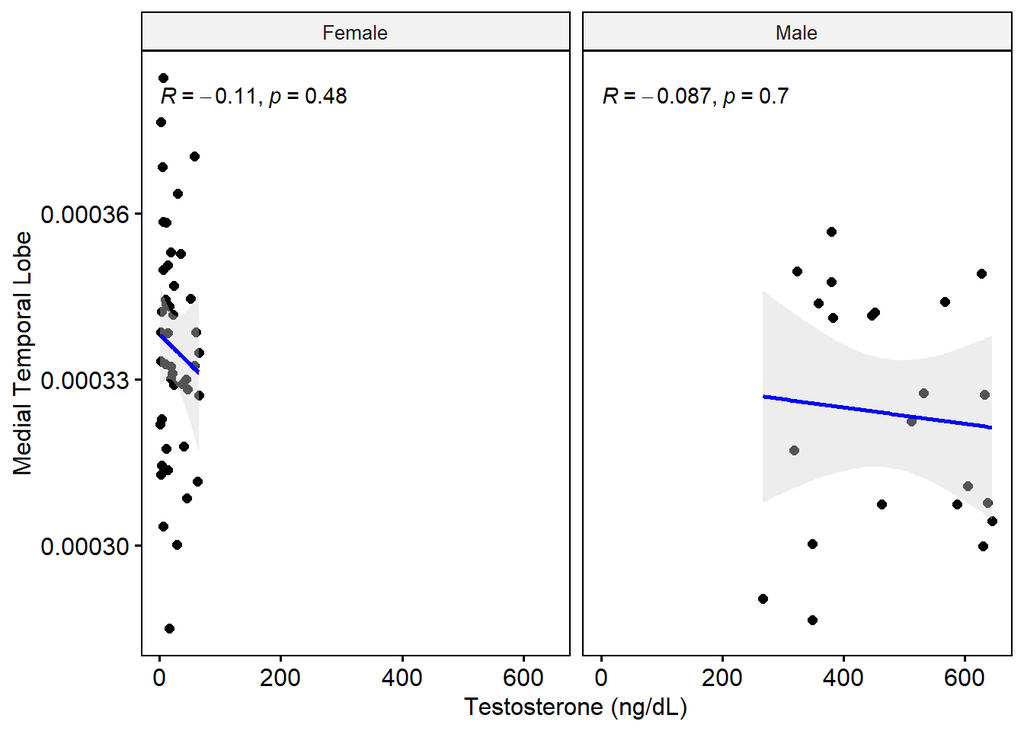

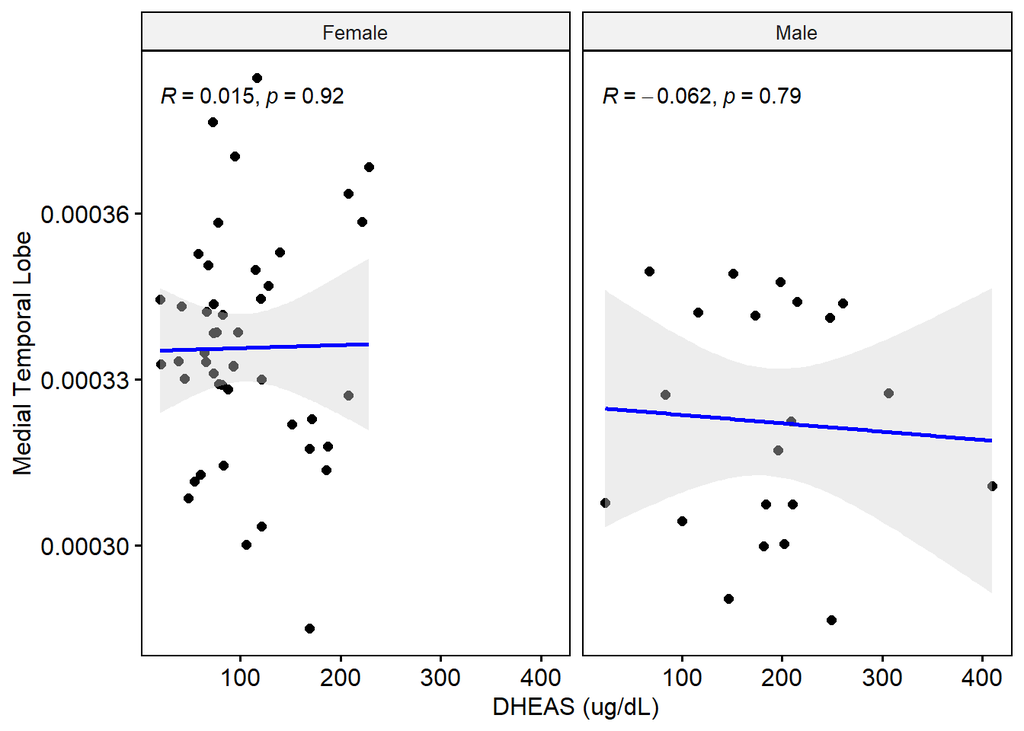

MTL volume as a somewhat negative association with FSH

## Parahippocampus

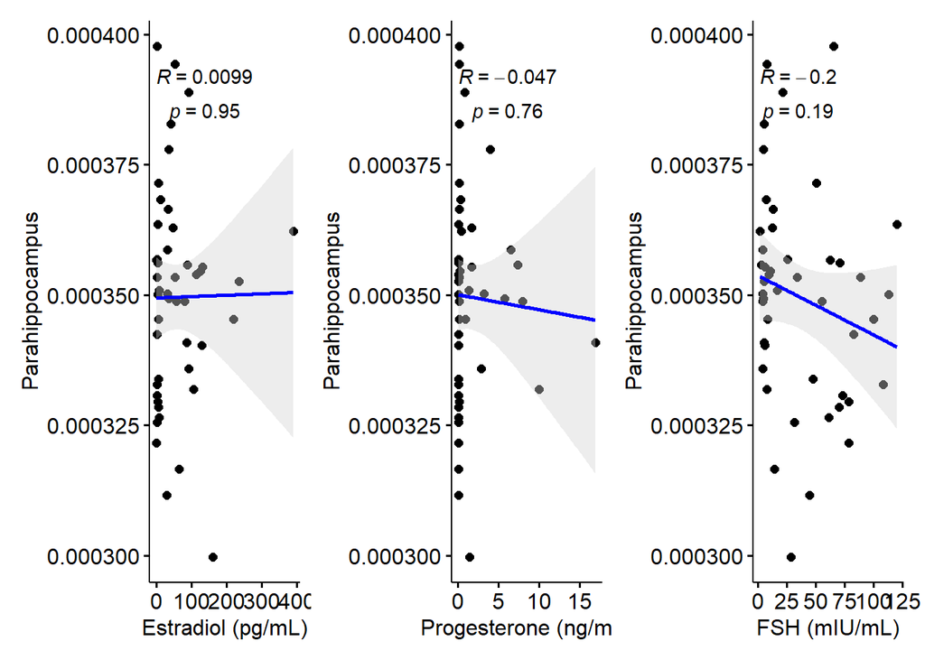

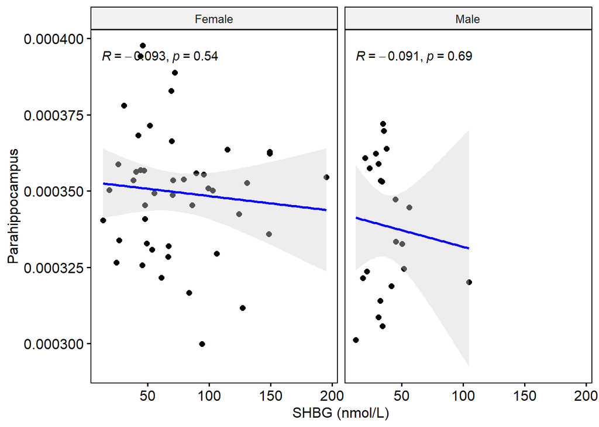

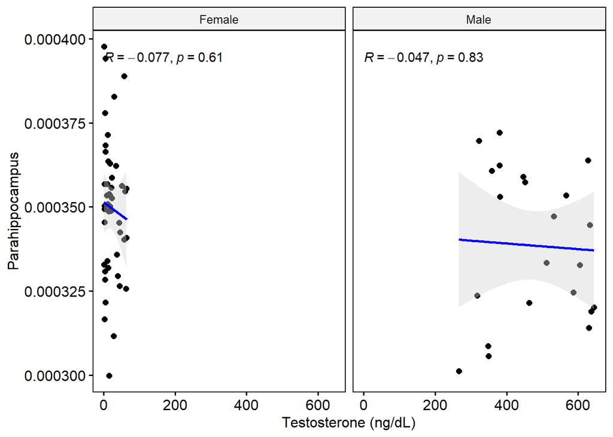

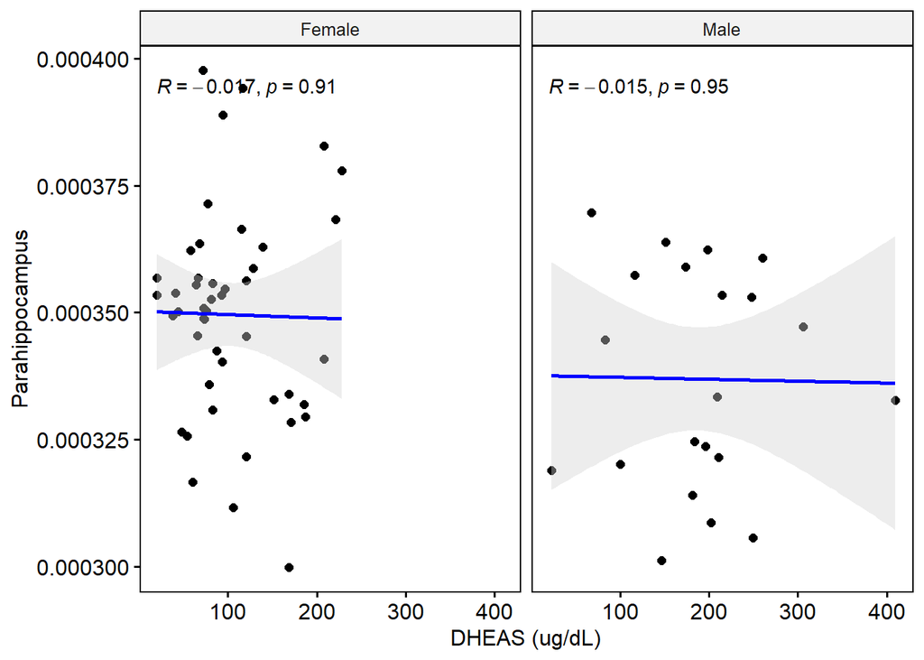

# T2 Subfield Volume

## CA1

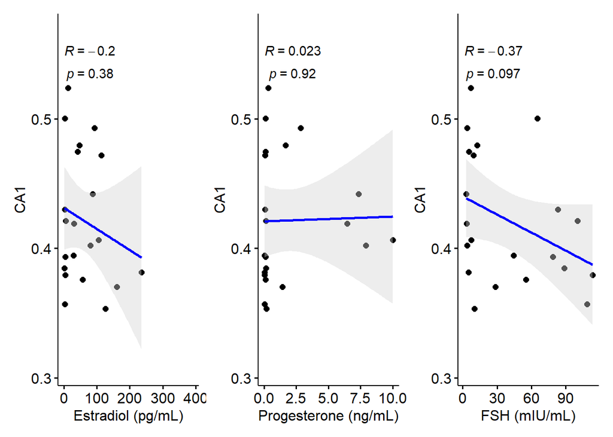

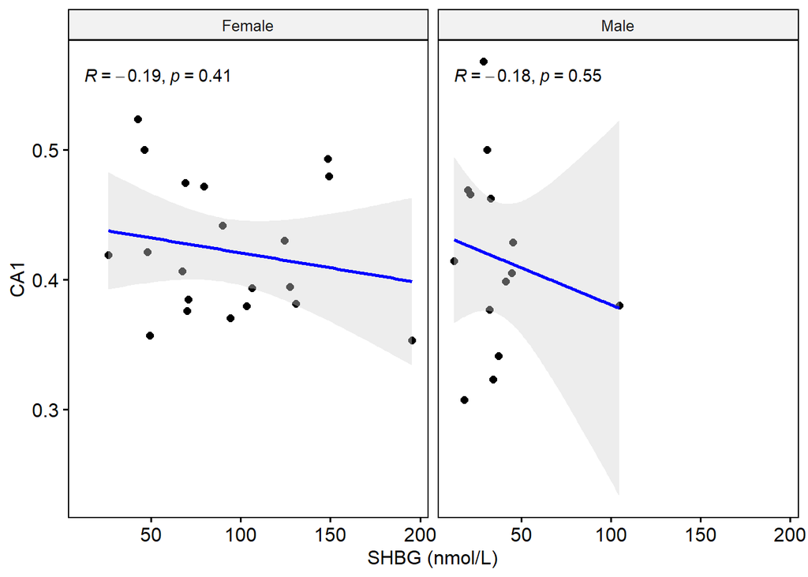

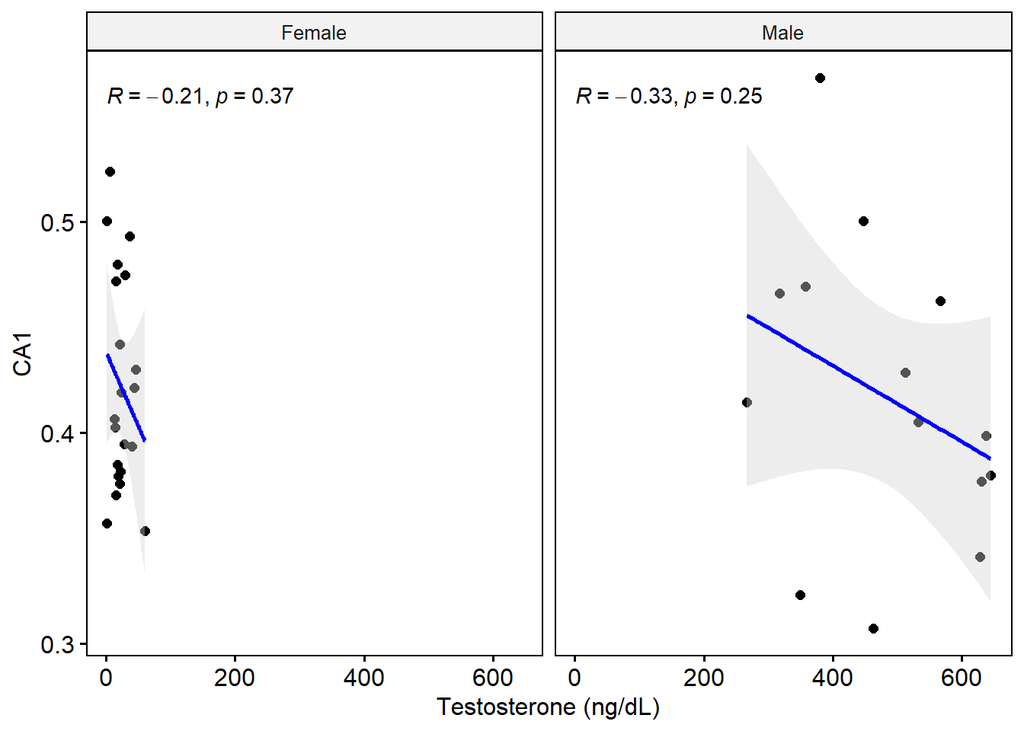

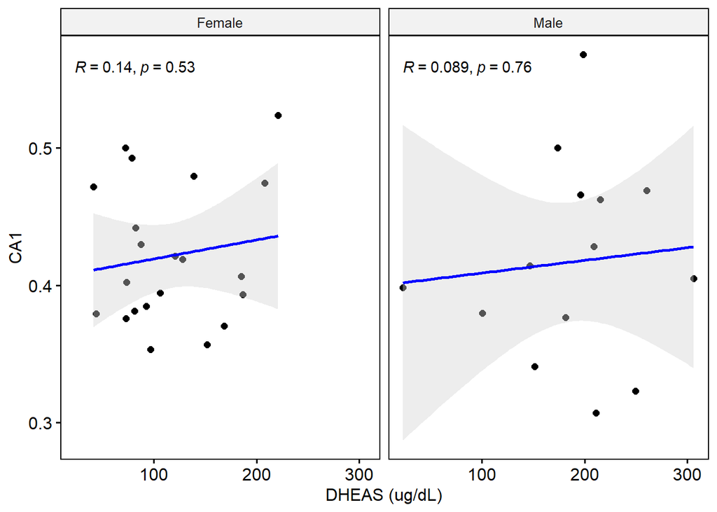

## CA2/3

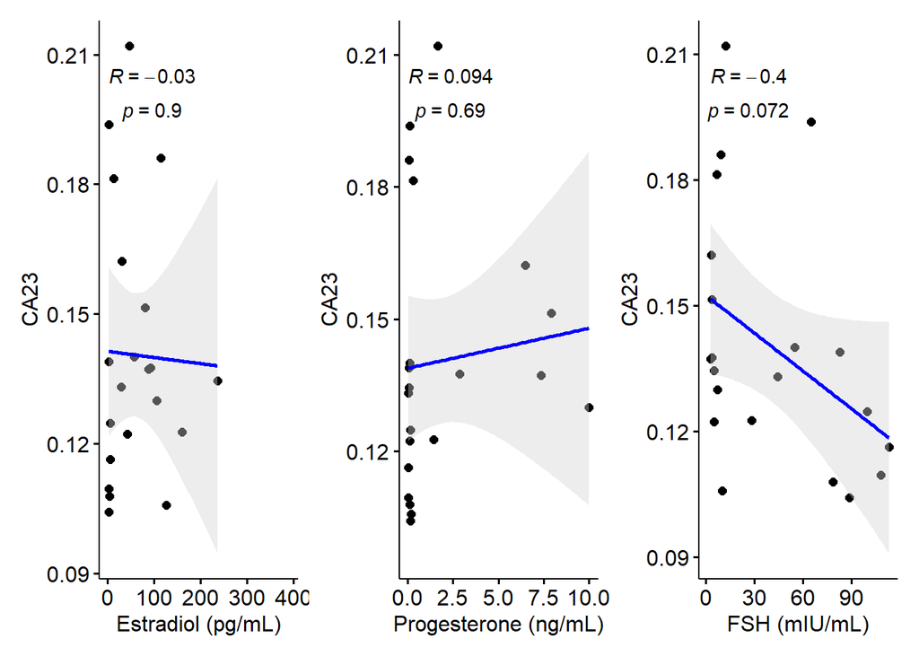

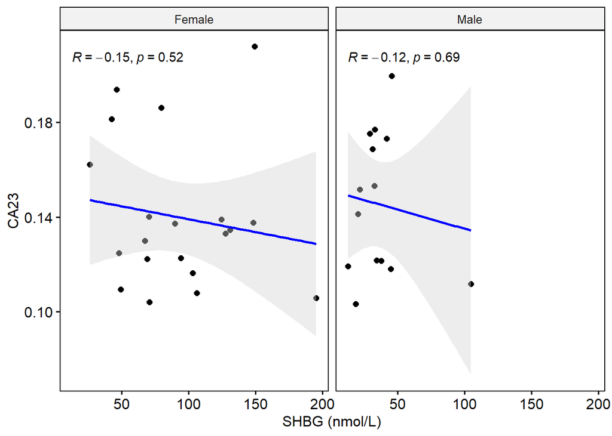

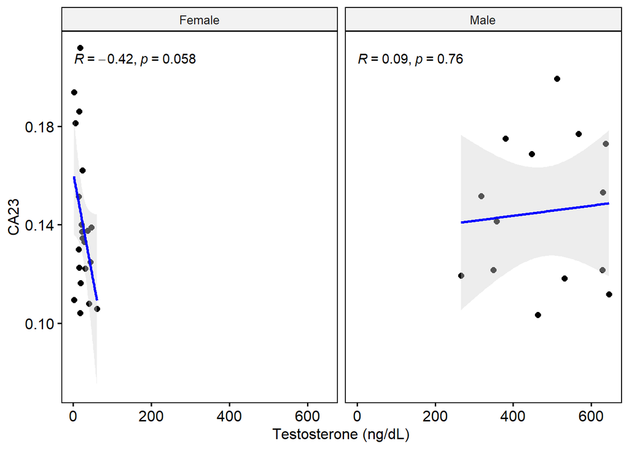

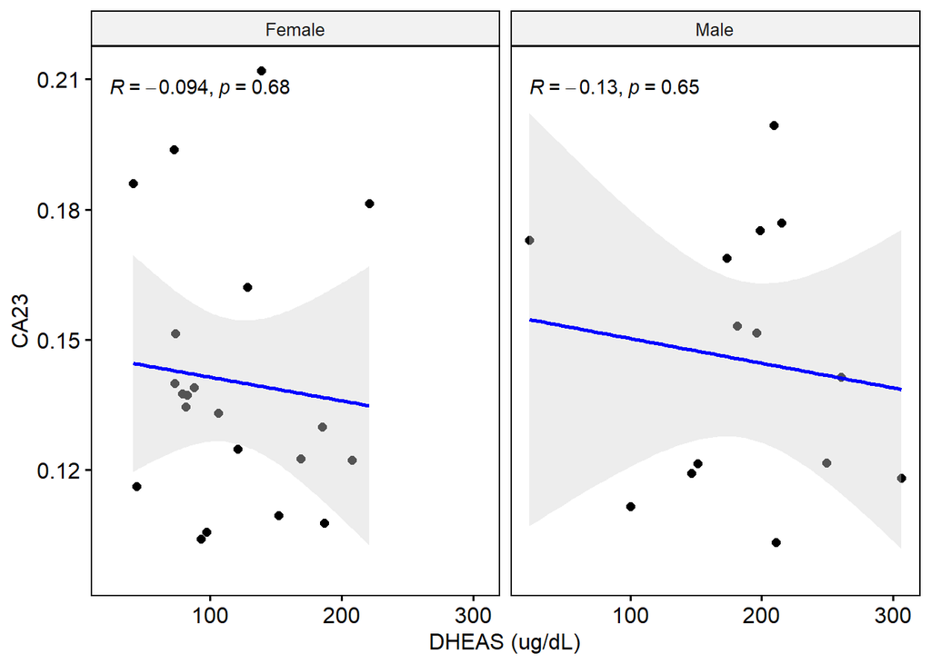

## DG

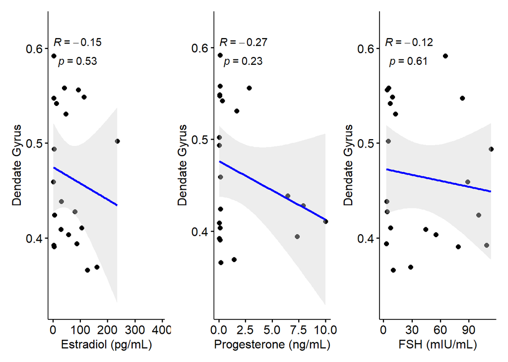

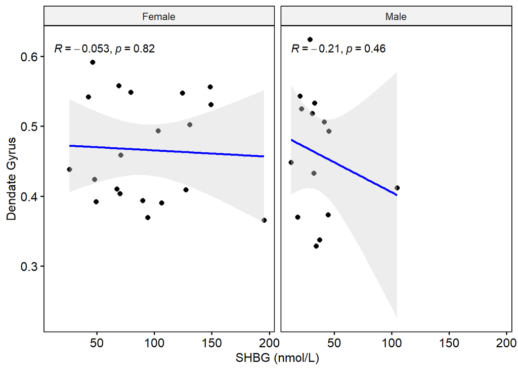

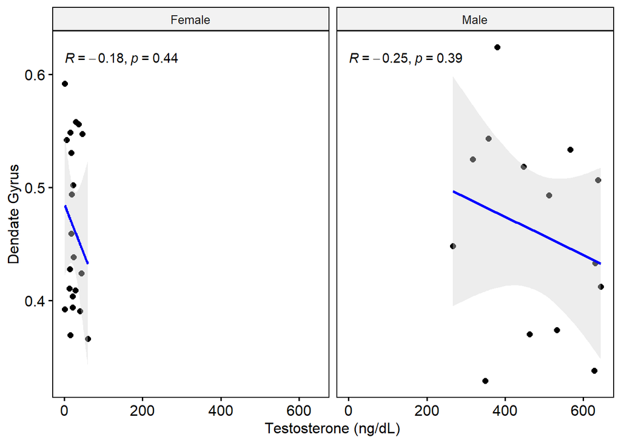

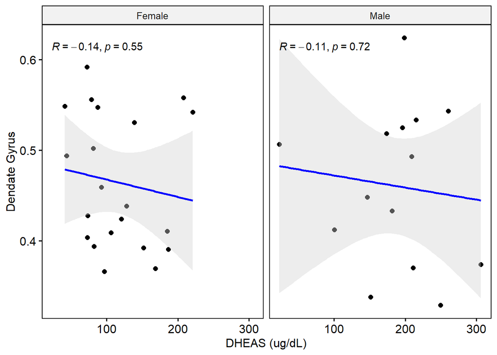

## ERC

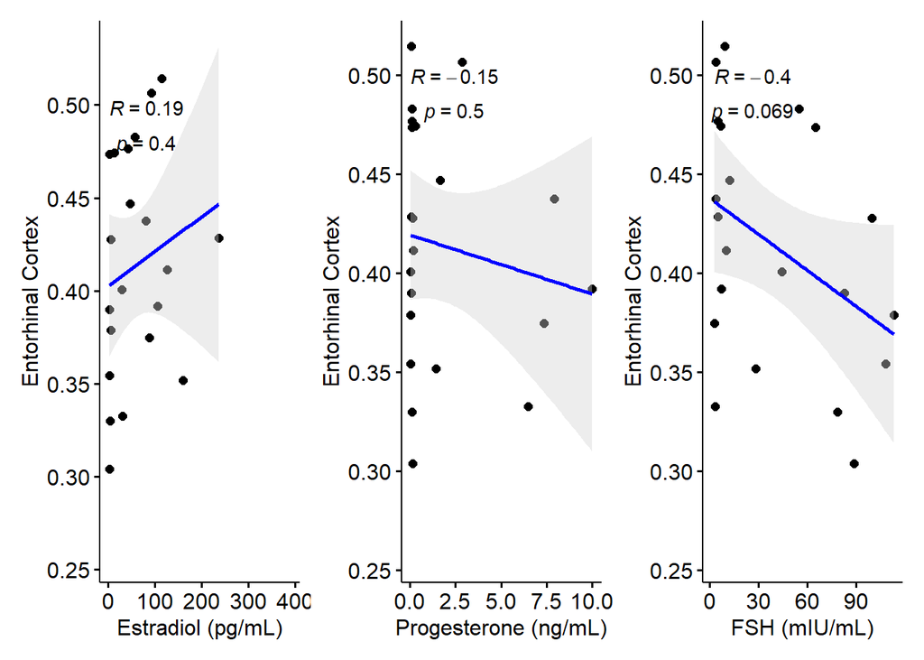

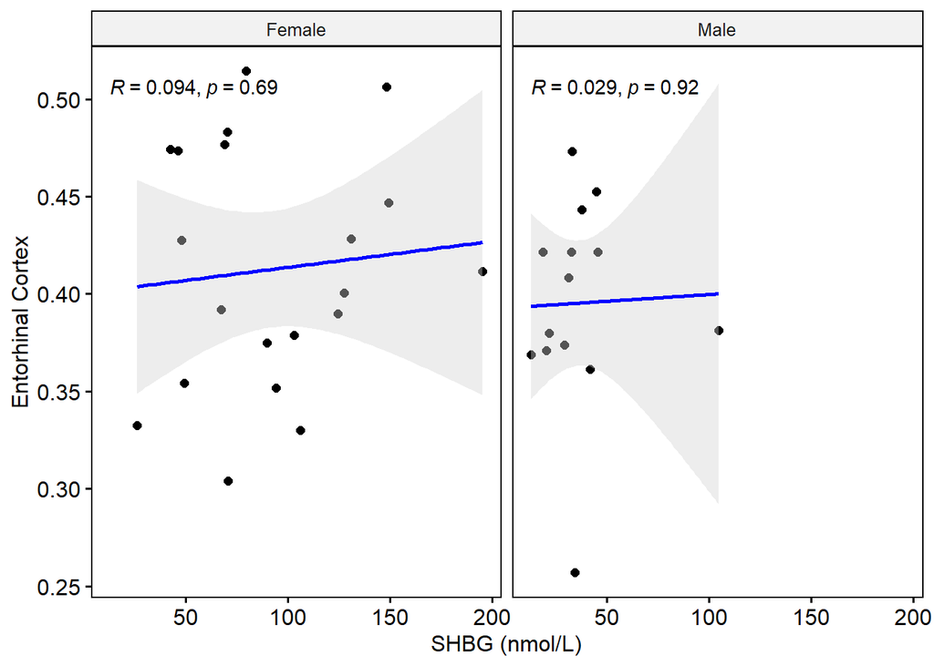

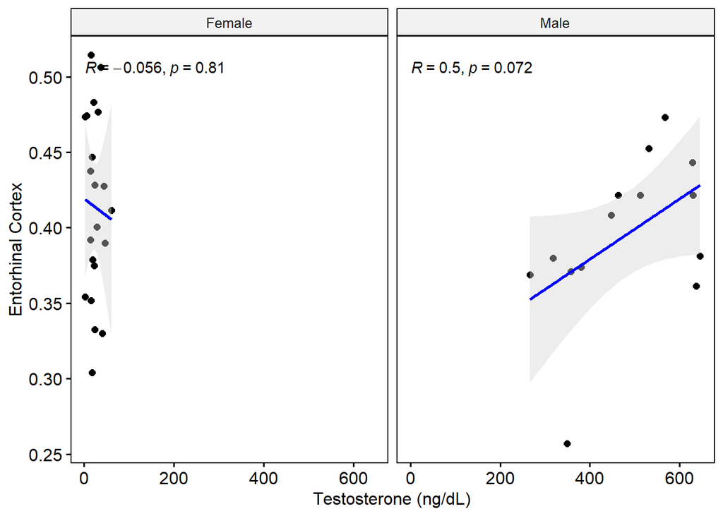

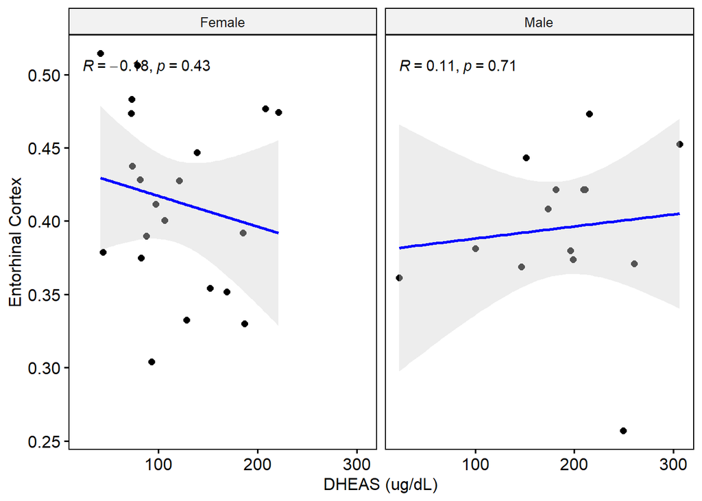